# Chapter 9: Tree based methods

Tree-based models form a broad class of nonparametric learning methods that recursively partition the feature space into smaller, non-overlapping regions that are relatively homogeneous with respect to the response variable. These methods are intuitive, interpretable, and capable of capturing complex structures in the data without relying on strict parametric assumptions.

Advantages using tree-based models:

Flexibility and Interpretability Tree-structured models are extremely flexible, capable of handling both categorical and continuous variables. They provide an intuitive and visual understanding of how predictors influence the response, making them ideal for both exploratory and predictive analyses.

Handling of Complex Interactions Tree-based models automatically account for high-order interactions among predictors. This makes them particularly effective when relationships among variables are complex or involve nonlinear or non-monotonic effects.

Robustness to Data Distribution and Scale Unlike many regression models, decision trees do not assume linear relationships, normality, or homoscedasticity. They are also invariant to monotonic transformations and scaling of predictors.

Ease of Implementation and Minimal Preprocessing Tree-based methods are simple to implement in R (e.g., using the rpart, tree, or caret packages). They require little data preprocessing—no need for variable standardization, transformation, or dummy coding.

Variable Selection and Insight Trees inherently perform variable selection by choosing the most informative predictors for splitting at each node. This can provide valuable insights about which features are most influential and can guide subsequent model refinement.

Adaptability to Various Applications Decision trees are widely used in numerous fields—such as linguistics, biology, finance, and public health—because they perform well with moderate sample sizes and mixed data types.

Tree-based approaches serve as the foundation for several advanced ensemble methods that improve prediction accuracy and stability, including:

Bagging (Bootstrap Aggregation) – e.g., Random Forests

Boosting – e.g., Gradient Boosted Trees (XGBoost, LightGBM)

Random Forests – Combining multiple decision trees built on bootstrapped samples and random subsets of features

### Decision Tree

A **Decision Tree** is a popular supervised machine learning algorithm used for both classification and regression tasks. It is a tree-like model consisting of several key components:

- **Root Node**: The topmost node in the tree, containing all the training data.
- **Internal Nodes**: Subgroups formed through a recursive process using binary partitions. Each internal node represents a feature or attribute, posing simple yes-or-no questions about the features to split the data.
- **Branches**: Connections that link the nodes together, representing decision rules or conditions.
- **Leaf Nodes (Terminal Nodes)**: The terminal subgroups at the bottom of the tree that represent predictions or class labels. The size of a tree is determined by the number of these terminal nodes.
- **Depth**: The depth of a tree corresponds to the length of the longest path from the root node to a leaf node.
- **Size**: Defined by the number of terminal nodes in the tree.

### How Decision Trees Work

A Decision Tree recursively partitions the data based on feature values, forming groups that become increasingly homogeneous with respect to the target variable. At each step, the algorithm selects the optimal feature and threshold that minimize impurity (in classification) or reduce prediction error (in regression). This recursive splitting continues until a specified stopping criterion is reached—such as a minimum node size, a maximum tree depth, or no further improvement in purity.

The resulting tree structure is intuitive, interpretable, and easy to visualize. Decision Trees can handle both categorical and numerical predictors and require minimal data preprocessing, as there is no need for variable standardization or dummy coding. Moreover, they provide transparent and easily interpretable decision rules, making them valuable for both exploratory analysis and predictive modeling.

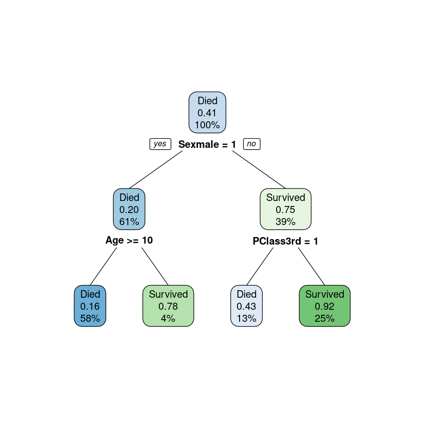

A decision tree is a general framework for representing decision rules through a hierarchical, tree-like structure. It can be applied to both classification and regression problems and encompasses a variety of algorithms including CART.

### CART (Classification And Regression Trees)

Among the various methodologies for constructing tree-based models, one of the most classical and influential approaches is the Classification and Regression Tree (CART) algorithm, introduced by Breiman, Friedman, Olshen, and Stone (1984). The CART algorithm recursively divides the training data into homogeneous subgroups, or regions of the predictor space where the response values are relatively similar. Within each terminal node (leaf), a constant prediction is assigned—typically the mean of the response for regression or the majority class for classification.

Geometrically, each leaf node corresponds to a hyper-rectangular region of the feature space, defined by a sequence of binary splitting rules on the predictors.

**Regression Trees**

For a regression tree, the model aims to minimize the Residual Sum of Squares (RSS) across all terminal regions: $$ R(T) = \sum_{j=1}^J\sum_{i:x_i\in R_j}(y_i-\hat{y}_{R_j})^2, $$

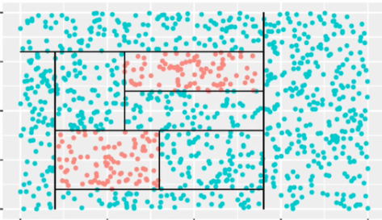

[Source: https://bookdown.org/hailiangdu/Lecture_notes/tree-based-models.html]

In practice, to balance between variance and bias and prevent overfitting, we frequently employ the 'weakest link pruning algorithm' to trim trees. The goal is to assess whether a smaller tree can yield comparable results to the fully grown tree. If this is the case, opting for the simpler tree is preferable, as it reduces the risk of overfitting.

The objective function (other similar variant version) with tuning parameter:

$$ R_{cp}(T) ≡ R(T) + c_p |T| R(T_1) $$

where $c_p$ is the tuning parameter (the complexity paramter), and $T_1$ is the tree without any splits.

**Classification Trees**

For **classification problems**, the CART algorithm divides the predictor space into regions that are increasingly **pure**, meaning that most observations within each region belong to a single class.  
Instead of minimizing squared error (as in regression trees), CART minimizes a measure of **node impurity**.

Let $\hat{p}_{mk}$ denote the proportion of training observations in node $m$ that belong to class $k$.  
Several impurity measures can be used:

- **Gini Index**

  $$ G_m = \sum_{k=1}^{K} \hat{p}_{mk}(1 - \hat{p}_{mk}) $$
- **Cross-Entropy (Deviance)**

  $$ D_m = -\sum_{k=1}^{K} \hat{p}_{mk}\log(\hat{p}_{mk}) $$
- **Classification Error Rate**

  $$ E_m = 1 - \max_k(\hat{p}_{mk}) $$

Among these, the **Gini index** and **cross-entropy** are the most commonly used because they are more sensitive to changes in node purity than the misclassification rate. Both the **Gini index** and **cross-entropy** measure how *pure* or *impure* a node is ( how mixed the classes are within that node). The Gini index increases as the class proportions become more evenly distributed and decreases as one class dominates. You may think of the Gini index as the *expected error rate* if you randomly assign class labels according to the observed class probabilities within that node. With the **Gini index**, CART produce nodes that are more homogeneous. The **cross-entropy** (also called **deviance** or **information gain**) measures the *information content* or *uncertainty* in class predictions. The Gini index is often preferred for computational efficiency, while cross-entropy aligns with the concept of **information gain** used in information theory.

- If all observations in a node belong to one class, say $\hat{p}_{mk}=1$ for some class $k$, then $G_m = 0$.  
  → The node is **pure**.
- If classes are perfectly mixed (e.g., for two classes $\hat{p}_{m1} = \hat{p}_{m2} = 0.5$),  
  then $G_m = 2(0.5)(0.5) = 0.5$.  
  → The node is **maximally impure**.

Consider a binary classification problem ($K=2$) with class probabilities $(p_1, p_2)$ within a node.  
We compare Gini impurity and cross-entropy for three different levels of purity:

| Class Distribution | Gini Index | Cross-Entropy |
| --- | --- | --- |
| $(0.5, 0.5)$ | $2(0.5)(0.5) = 0.50$ | $- [0.5\log(0.5) + 0.5\log(0.5)] = 0.693$ |
| $(0.9, 0.1)$ | $2(0.9)(0.1) = 0.18$ | $- [0.9\log(0.9) + 0.1\log(0.1)] = 0.325$ |
| $(1.0, 0.0)$ | $2(1)(0) = 0.00$ | $- [1\log(1) + 0\log(0)] = 0.000$ |

Both measures decrease as one class becomes dominant (i.e., the node becomes purer).  
When the classes are perfectly mixed, both impurity measures reach their maximum values.

```
Numerical illustration (binary):
         Distribution Gini CrossEntropy
1 Balanced (0.5, 0.5) 0.50    0.6931472
2 Skewed   (0.9, 0.1) 0.18    0.3250830
3 Pure     (1.0, 0.0) 0.00    0.0000000

Impurity by terminal node (training data):
  NodeID  N Prob_Setosa Prob_Versicolor Prob_Virginica   Gini CrossEntropy
2      2 50           1      0.00000000     0.00000000 0.0000       0.0000
5      5 48           0      0.97916667     0.02083333 0.0408       0.1013
7      7  3           0      0.66666667     0.33333333 0.4444       0.6365
8      8  3           0      0.00000000     1.00000000 0.0000       0.0000
9      9 46           0      0.02173913     0.97826087 0.0425       0.1047

Classification tree:
rpart(formula = Species ~ ., data = iris, method = "class", control = rpart.control(cp = 0.001,
    minsplit = 5, maxdepth = 5))

Variables actually used in tree construction:
[1] Petal.Length Petal.Width

Root node error: 100/150 = 0.66667

n= 150

     CP nsplit rel error xerror     xstd
1 0.500      0      1.00   1.19 0.049592
2 0.440      1      0.50   0.70 0.061101
3 0.020      2      0.06   0.07 0.025833
4 0.010      3      0.04   0.08 0.027520
5 0.001      4      0.03   0.07 0.025833
```

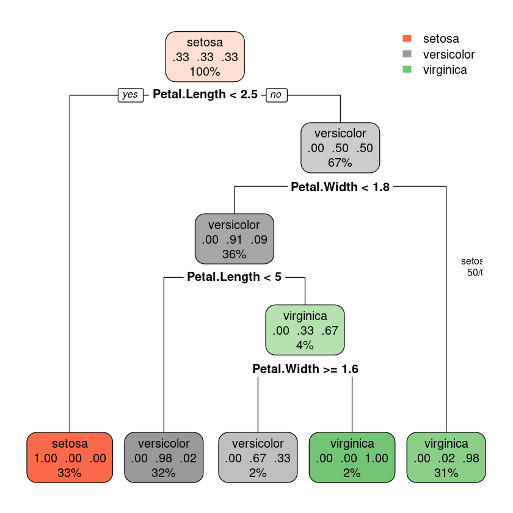

```r
# Load package
library(rpart)    # CART implementation

# ------------------------------------------------------------
# 1. Define helper functions for impurity
# ------------------------------------------------------------

# Gini index: measures expected misclassification rate
gini = function(p) {
  p = p[p > 0]                      # ignore zeros
  sum(p * (1 - p))
}

# Cross-entropy (deviance): measures information uncertainty
cross_entropy = function(p) {
  p = p[p > 0]                      # drop zeros to avoid log(0)
  -sum(p * log(p))                  # natural-log entropy
}

# ------------------------------------------------------------
# Numerical illustration for binary classification nodes
# ------------------------------------------------------------
p_list = list(
  "Balanced (0.5, 0.5)" = c(0.5, 0.5),
  "Skewed   (0.9, 0.1)" = c(0.9, 0.1),
  "Pure     (1.0, 0.0)" = c(1.0, 0.0)
)

example_df = data.frame(
  Distribution  = names(p_list),
  Gini          = sapply(p_list, gini),
  CrossEntropy  = sapply(p_list, cross_entropy),
  row.names = NULL
)

cat("Numerical illustration (binary):\n")
print(example_df)

# ------------------------------------------------------------
# Fit a CART classification tree using the iris dataset
# ------------------------------------------------------------
set.seed(6021)   # reproducibility

fit = rpart(
  Species ~ .,
  data = iris,
  method = "class",
  control = rpart.control(cp = 0.001, minsplit = 5, maxdepth = 5)
)

# Quick visual check of the fitted tree
 rpart.plot::rpart.plot(fit)
text(fit, use.n = TRUE, cex = 0.8)

# ------------------------------------------------------------
# Compute node impurity for each terminal node
# ------------------------------------------------------------
node_id = fit$where                   # terminal node ID for each observation
tbl = table(node_id, iris$Species)    # class counts per node

# Convert counts to class probabilities
row_sums = rowSums(tbl)
probs = sweep(tbl, 1, row_sums, FUN = "/")

# Compute Gini and Cross-Entropy for each node
node_gini = apply(probs, 1, function(p) gini(as.numeric(p)))
node_ce   = apply(probs, 1, function(p) cross_entropy(as.numeric(p)))

# Create a tidy summary table
terminal_summary = data.frame(
  NodeID = as.integer(rownames(probs)),
  N = as.integer(row_sums),
  Prob_Setosa = as.numeric(probs[, "setosa"]),
  Prob_Versicolor = as.numeric(probs[, "versicolor"]),
  Prob_Virginica = as.numeric(probs[, "virginica"]),
  Gini = round(node_gini, 4),
  CrossEntropy = round(node_ce, 4)
)

terminal_summary = terminal_summary[order(terminal_summary$NodeID), ]

cat("\nImpurity by terminal node (training data):\n")
print(terminal_summary)

# Cost-Complexity Pruning
# ------------------------------------------------------------
 cp_table = printcp(fit)                      # show cross-validated error
 best_cp = cp_table[which.min(cp_table[,"xerror"]), "CP"]
 fit_pruned = prune(fit, cp = best_cp)        # pruned tree if desired

# Notes:
# - Both Gini and Cross-Entropy decrease as nodes become purer.
# - Cross-Entropy here uses natural log; for base-2 log, divide by log(2).
# - For cleaner visualization, try: rpart.plot::rpart.plot(fit)
```

| Rule Path | Predicted Class | Node Purity | Comment |
| --- | --- | --- | --- |
| Petal.Length < 2.5 | setosa | 100% | Perfectly pure split |
| Petal.Length ≥ 2.5 & Petal.Width < 1.8 & Petal.Length < 5 | versicolor | 98% | Very pure node |
| Petal.Length ≥ 2.5 & Petal.Width ≥ 1.8 | virginica | 98–100% | Very pure nodes |

The first and most powerful split, Petal.Length < 2.5, completely isolates all setosa flowers, yielding a terminal node with 100% purity and a Gini index of 0, indicating no class uncertainty. The remaining data, consisting of versicolor and virginica, is further divided by Petal.Width < 1.8, which substantially reduces impurity by separating most versicolor samples from virginica. Subsequent fine splits such as Petal.Length < 5 and Petal.Width ≥ 1.6 continue to decrease node impurity until each leaf is nearly pure. This progressive reduction in Gini or cross-entropy impurity at each level of the tree demonstrates how CART efficiently identifies the most informative features and thresholds, leading to a simple yet highly accurate classification rule: setosa is defined by short petals, versicolor by moderate petal width, and virginica by wider petals.

# Cart for regression

```r
# Build a CART tree model to predict "medv" using all other features in Boston housing data
library(MASS)
library(tidyverse)
library(caret)

#There are 14 varables:  medv is the price of house (response)
data(Boston)
str(Boston)

set.seed(252)

#Transformed data
#Boston.dat = Boston %>%  mutate_all(scale.fun)
#Split the data
#Split the data into training and testing set according to medv

index = createDataPartition(Boston$medv, p = 0.8, list = FALSE)
train.dat = Boston[index,]
test.dat =   Boston[-index,]
```

```
'data.frame':	506 obs. of  14 variables:
 $ crim   : num  0.00632 0.02731 0.02729 0.03237 0.06905 ...
 $ zn     : num  18 0 0 0 0 0 12.5 12.5 12.5 12.5 ...
 $ indus  : num  2.31 7.07 7.07 2.18 2.18 2.18 7.87 7.87 7.87 7.87 ...
 $ chas   : int  0 0 0 0 0 0 0 0 0 0 ...
 $ nox    : num  0.538 0.469 0.469 0.458 0.458 0.458 0.524 0.524 0.524 0.524 ...
 $ rm     : num  6.58 6.42 7.18 7 7.15 ...
 $ age    : num  65.2 78.9 61.1 45.8 54.2 58.7 66.6 96.1 100 85.9 ...
 $ dis    : num  4.09 4.97 4.97 6.06 6.06 ...
 $ rad    : int  1 2 2 3 3 3 5 5 5 5 ...
 $ tax    : num  296 242 242 222 222 222 311 311 311 311 ...
 $ ptratio: num  15.3 17.8 17.8 18.7 18.7 18.7 15.2 15.2 15.2 15.2 ...
 $ black  : num  397 397 393 395 397 ...
 $ lstat  : num  4.98 9.14 4.03 2.94 5.33 ...
 $ medv   : num  24 21.6 34.7 33.4 36.2 28.7 22.9 27.1 16.5 18.9 ...
```

3.26509476729593

4.6377936979857

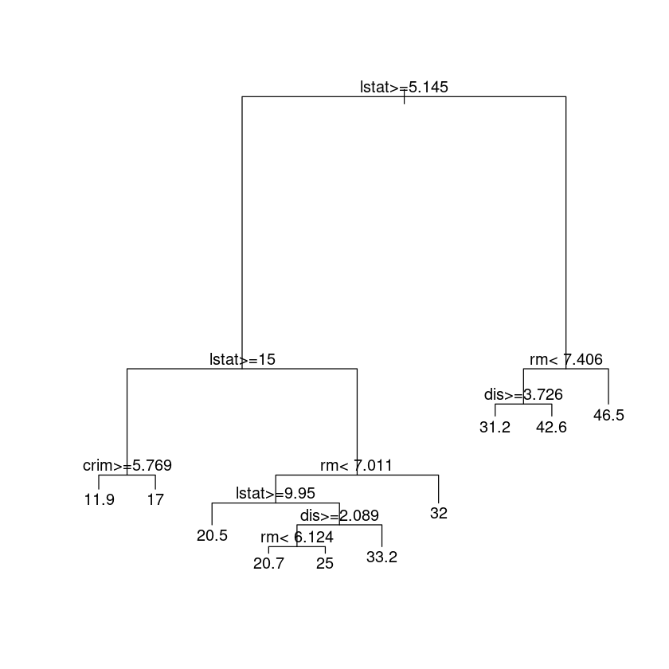

```r
#rpart :  Recursive Partitioning and Regression Trees
#rpart is another name of CART in R
library(rpart)

#build a CART on the training data
fit.rpart = rpart(medv ~., data = train.dat)

#To show the regression tree
plot(fit.rpart)
text(fit.rpart, digits = 3)

#Make a predict on the testing data
yhat = predict(fit.rpart, test.dat )

#Find the MAE of the tree model on the testing data
caret::MAE(test.dat$medv, yhat)
caret::RMSE(test.dat$medv, yhat)


#What the predicted value for a house train.dat[2,]
#This case : 3	0.02729	0	7.07	0	0.469	7.185	61.1	4.9671	2	242	17.8	392.83	4.03	34.7
#The predicted medv = 31.2

#The RMSE 4.63 is mucher higher than that of previous methods (please check the previous notes)
```

Overall, the result clearly demonstrates that **socioeconomic status (`lstat`) is the dominant predictor** of housing value, with **structural characteristics (`rm`)** and **environmental factors (`crim`, `dis`)** refining the predictions. Affluent neighborhoods with large homes achieve the highest predicted values, while high-poverty, high-crime areas correspond to the lowest.

[output not shown]

```r
# ------------------------------------------------------------
#  Fit a regression tree on the training data
# ------------------------------------------------------------
fit.rpart = rpart(
  medv ~ .,
  data = train.dat,
  method = "anova",                    # regression tree
  control = rpart.control(cp = 0.001,  # complexity parameter
                          minsplit = 10,
                          maxdepth = 6)
)
```

| Parameter | Purpose | Effect |
| --- | --- | --- |
| `cp = 0.001` | Minimum relative improvement in model fit for a split | Smaller value → larger, more detailed tree |
| `minsplit = 10` | Minimum number of observations in a node before splitting | Prevents overfitting from small sample splits |
| `maxdepth = 6` | Maximum number of levels in the tree | Limits overall complexity and improves interpretability |

```r
#Select the optimal CP (tuning parameter) using R train function

set.seed(527)
#Cross validation :  10 folder cross validation
ctrl  =  trainControl(method  = "cv", number  = 10)

#Tuning parameter: the complexity parameter (cp),
#which imposes a penalty to the tree for having two many splits.
#The default value is 0.01. The higher the cp, the smaller the tree.
#A too small value of cp leads to overfitting and a too large cp value will result to a too small tree. Both cases decrease the predictive performance of the model.
#An optimal cp value can be estimated by testing different cp values and using cross-validation approaches.

#To create the searching grid
tgrid = expand.grid(
 cp= c(0.000001, 0.0001, 0.0002,  0.001, 0.002)
)

fit.rpart1 =  train(medv ~ ., data = train.dat,
                     method = "rpart", trControl = ctrl, tuneGrid =tgrid)

fit.rpart1 =  train(medv ~ ., data = train.dat,
                     method = "rpart", trControl = ctrl, tuneLength =10)
fit.rpart1

fit.rpart1$bestTune

#plot(fit.rpart1)

#Eveluate the model using the testing data

yhat = predict(fit.rpart, test.dat )

#Find the MAE of the tree model on the testing data
caret::MAE(test.dat$medv, yhat)
caret::RMSE(test.dat$medv, yhat)
caret::R2(test.dat$medv, yhat)
```

[output not shown]

A data.frame: 1 × 1

|  | cp <dbl> |
| --- | --- |
| 1 | 0.002795865 |

3.26509476729593

4.6377936979857

0.73517874289441

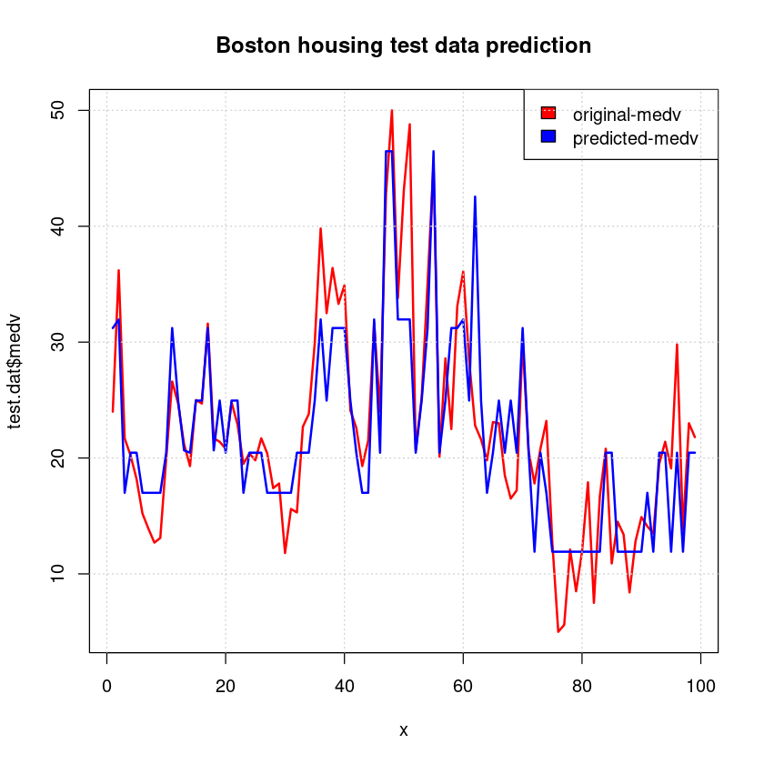

```r
#Line plots to see the performance
#Predicted value vs observed values
x = 1:length(yhat)
plot(x, test.dat$medv, col = "red", type = "l", lwd=2,
     main = "Boston housing test data prediction")
lines(x, yhat, col = "blue", lwd=2)
legend("topright",  legend = c("original-medv", "predicted-medv"),
       fill = c("red", "blue"), col = 2:3,  adj = c(0, 0.6))
grid()
```

# CART for classification

Example: The data description is at

# https://search.r-project.org/CRAN/refmans/pdp/html/pima.html

The purpose is to construct a predictive model to predict if a person has "diabetes" or not based on all other features in the data.

Response: diabetes ( Negative or Positive). A binary classification problem.

```r
library(caret) #ML Model buidling package
 library(MASS) #Modern Applied Statistics with S
 library(mlbench) #data sets from the UCI repository.

data(PimaIndiansDiabetes)
dat = PimaIndiansDiabetes

str(dat)
```

```
'data.frame':	768 obs. of  9 variables:
 $ pregnant: num  6 1 8 1 0 5 3 10 2 8 ...
 $ glucose : num  148 85 183 89 137 116 78 115 197 125 ...
 $ pressure: num  72 66 64 66 40 74 50 0 70 96 ...
 $ triceps : num  35 29 0 23 35 0 32 0 45 0 ...
 $ insulin : num  0 0 0 94 168 0 88 0 543 0 ...
 $ mass    : num  33.6 26.6 23.3 28.1 43.1 25.6 31 35.3 30.5 0 ...
 $ pedigree: num  0.627 0.351 0.672 0.167 2.288 ...
 $ age     : num  50 31 32 21 33 30 26 29 53 54 ...
 $ diabetes: Factor w/ 2 levels "neg","pos": 2 1 2 1 2 1 2 1 2 2 ...
```

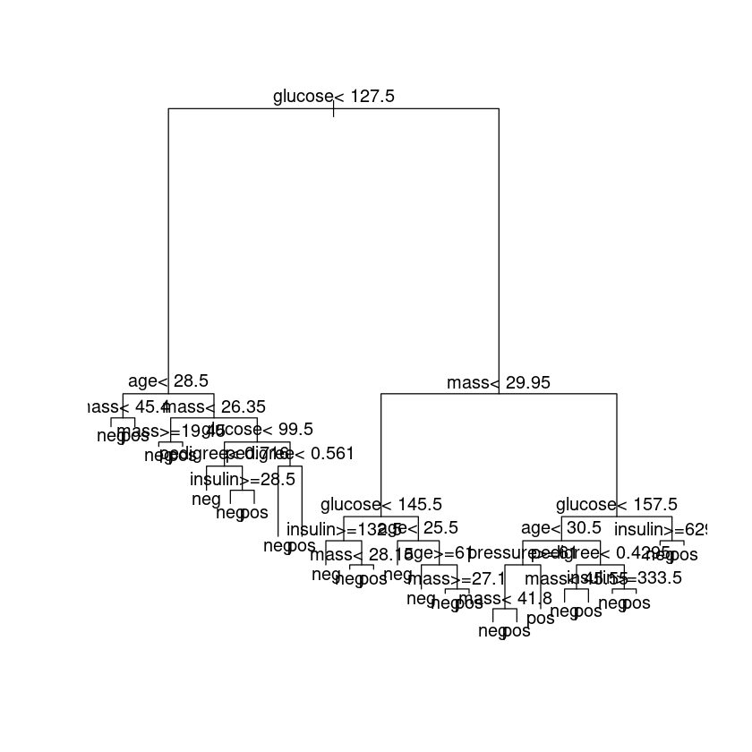

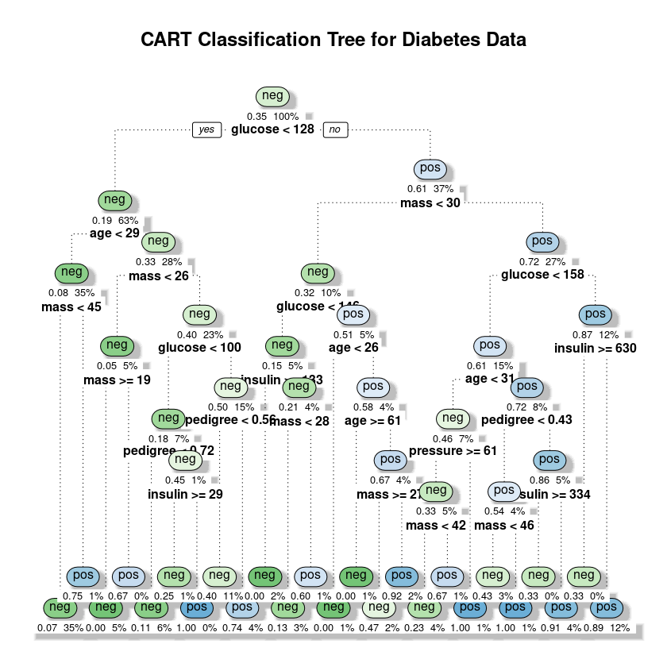

```r
#rpart :  Recursive Partitioning and Regression Trees
#rpart is another name of CART in R
#build a CART on the training data
library(rpart)
library(rpart.plot)


# ------------------------------------------------------------
# Build a CART model on the training data
# ------------------------------------------------------------
fit.rpart = rpart(
  diabetes ~ .,           # response and predictors
  data = dat,             # dataset
  method = "class",       # "class" for classification, "anova" for regression
  control = rpart.control(
    cp = 0.001,           # complexity parameter (controls pruning)
    minsplit = 10,        # minimum number of observations to attempt a split
    maxdepth = 6          # maximum depth of the tree
  )
)


#To show the regression tree
plot(fit.rpart)
text(fit.rpart, digits = 3)

# Clear, readable plot
rpart.plot(
  fit.rpart,
  type = 2,             # 0 = label below node, 2 = label inside node
  extra = 106,          # show class, prob, and % observations
  under = TRUE,         # add text under the boxes
  faclen = 0,           # do not abbreviate factor levels
  box.palette = "GnBu", # color scale (Blue-Green)
  branch.lty = 3,       # dashed branches
  shadow.col = "gray",  # add shadow for clarity
  cex = 0.8,            # control text size
  main = "CART Classification Tree for Diabetes Data"
)
```

```r
#Make a predict on the data
yhat = predict(fit.rpart, dat, type="class")

#Confusion matrix
#table(yhat, dat$diabetes)
#Confusion matrix
confusionMatrix(yhat, reference = dat$diabetes)
```

```
Confusion Matrix and Statistics

          Reference
Prediction neg pos
       neg 449  72
       pos  51 196

               Accuracy : 0.8398
                 95% CI : (0.812, 0.8651)
    No Information Rate : 0.651
    P-Value [Acc > NIR] : < 2e-16

                  Kappa : 0.641

 Mcnemar's Test P-Value : 0.07133

            Sensitivity : 0.8980
            Specificity : 0.7313
         Pos Pred Value : 0.8618
         Neg Pred Value : 0.7935
             Prevalence : 0.6510
         Detection Rate : 0.5846
   Detection Prevalence : 0.6784
      Balanced Accuracy : 0.8147

       'Positive' Class : neg
```

```r
# ------------------------------------------------------------
#    - minsplit:  node must have ≥ this many rows to consider a split
#    - minbucket: each terminal (leaf) must have ≥ this many rows
#    - maxdepth:  maximum number of splits from root to any leaf
#    - cp:        minimum relative improvement required to split
# ------------------------------------------------------------
cntrl = rpart.control(
  minsplit = 10,
  minbucket = 3,
  maxdepth = 20,
  cp = 0.001
)

# ------------------------------------------------------------
# Fit the CART classifier
# ------------------------------------------------------------
fit = rpart(
  diabetes ~ .,
  data = dat,
  method = "class",
  control = cntrl
)

# ------------------------------------------------------------
# Predictions and Confusion Matrix (on the same data)
#    Note: evaluating on training data inflates accuracy.
# ------------------------------------------------------------
yhat = predict(fit, newdata = dat, type = "class")

# Ensure the prediction factor has the same level order as the truth
yhat = factor(yhat, levels = levels(dat$diabetes))

cm = confusionMatrix(data = yhat, reference = dat$diabetes)
cm
```

```
Confusion Matrix and Statistics

          Reference
Prediction neg pos
       neg 466  30
       pos  34 238

               Accuracy : 0.9167
                 95% CI : (0.8948, 0.9352)
    No Information Rate : 0.651
    P-Value [Acc > NIR] : <2e-16

                  Kappa : 0.8172

 Mcnemar's Test P-Value : 0.7077

            Sensitivity : 0.9320
            Specificity : 0.8881
         Pos Pred Value : 0.9395
         Neg Pred Value : 0.8750
             Prevalence : 0.6510
         Detection Rate : 0.6068
   Detection Prevalence : 0.6458
      Balanced Accuracy : 0.9100

       'Positive' Class : neg
```

```r
#Split the data into train set and test set

library(caret)

dat = PimaIndiansDiabetes
set.seed(252)
index = createDataPartition(dat$diabetes, p = 0.8, list = FALSE)
train.dat = dat[index,]
test.dat =   dat[-index,]
```

```
Confusion Matrix and Statistics

          Reference
Prediction neg pos
       neg  81  20
       pos  19  33

               Accuracy : 0.7451
                 95% CI : (0.6684, 0.812)
    No Information Rate : 0.6536
    P-Value [Acc > NIR] : 0.009661

                  Kappa : 0.4346

 Mcnemar's Test P-Value : 1.000000

            Sensitivity : 0.8100
            Specificity : 0.6226
         Pos Pred Value : 0.8020
         Neg Pred Value : 0.6346
             Prevalence : 0.6536
         Detection Rate : 0.5294
   Detection Prevalence : 0.6601
      Balanced Accuracy : 0.7163

       'Positive' Class : neg
```

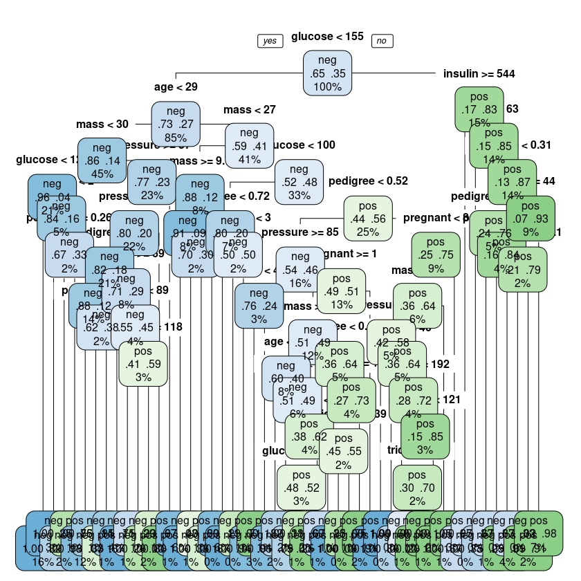

```r
# 1) Controls
cntrl = rpart.control(
  minsplit = 10,
  minbucket = 3,
  maxdepth = 20,
  cp = 0.001           # add a reasonable complexity parameter
)

# 2) Fit on training data
fit = rpart(
  diabetes ~ .,
  data = train.dat,
  method = "class",
  control = cntrl
)

# 3) Plot (clearer than base plot)
#rpart.plot(fit, type = 2, extra = 106, fallen.leaves = TRUE,
#           box.palette = "GnBu", cex = 0.8,
#           main = "")

rpart.plot(fit, type = 1, extra = 104, cex = 0.8)


# 4) Predict on the TEST set and evaluate
yhat = predict(fit, newdata = test.dat, type = "class")
yhat = factor(yhat, levels = levels(test.dat$diabetes))   # align levels

cm = confusionMatrix(data = yhat, reference = test.dat$diabetes)
cm
```

| Option | What it does | Example / Tip |
| --- | --- | --- |
| **`type`** | Controls the layout of labels and nodes | `type = 1` – labels below nodes (default) `type = 2` – labels inside boxes *(cleaner)* |
| **`extra`** | Adds more info inside nodes | `extra = 101` – class only `extra = 104` – class + prob `extra = 106` – class + prob + % obs |
| **`fallen.leaves`** | Aligns all leaf nodes at the bottom | `fallen.leaves = TRUE` for a neat look |
| **`box.palette`** | Color scheme for class purity | Try `"GnBu"`, `"Blues"`, `"RdYlGn"`, or `"Greens"` |
| **`cex`** | Text size | `cex = 0.8` (smaller) or `cex = 1.2` (larger) |
| **`tweak`** | Scales the whole diagram | `tweak = 1.2` makes boxes slightly larger |
| **`branch.lty`** | Line type for branches | `branch.lty = 3` makes dashed lines |
| **`main`** | Plot title | `main = "CART Tree for Diabetes"` |

```r
#Train a CART (rpart) by caret train function

# 1) Set seed for reproducibility
set.seed(527)

# 2) Define 10-fold cross-validation
ctrl = trainControl(
  method = "cv",      # cross-validation
  number = 10         # 10 folds
)

# 3) Train a CART model using rpart
fit.rpart1 = train(
  diabetes ~ .,
  data = train.dat,
  method = "rpart",   # use CART (rpart) method
  trControl = ctrl,   # cross-validation setup
  tuneLength = 20     # number of cp (complexity parameter) values to try
)

fit.rpart1
```

```
CART

615 samples
  8 predictor
  2 classes: 'neg', 'pos'

No pre-processing
Resampling: Cross-Validated (10 fold)
Summary of sample sizes: 553, 553, 553, 554, 553, 554, ...
Resampling results across tuning parameters:

  cp          Accuracy   Kappa
  0.00000000  0.7152036  0.3689258
  0.01468788  0.7397144  0.4051886
  0.02937576  0.7283184  0.3369999
  0.04406365  0.7300106  0.3241314
  0.05875153  0.7251719  0.3166013
  0.07343941  0.7251719  0.3166013
  0.08812729  0.7251719  0.3166013
  0.10281518  0.7251719  0.3166013
  0.11750306  0.7251719  0.3166013
  0.13219094  0.7251719  0.3166013
  0.14687882  0.7251719  0.3166013
  0.16156671  0.7251719  0.3166013
  0.17625459  0.7251719  0.3166013
  0.19094247  0.7251719  0.3166013
  0.20563035  0.7251719  0.3166013
  0.22031824  0.7251719  0.3166013
  0.23500612  0.7251719  0.3166013
  0.24969400  0.7187203  0.2775183
  0.26438188  0.7042041  0.2279563
  0.27906977  0.7042041  0.2279563

Accuracy was used to select the optimal model using the largest value.
The final value used for the model was cp = 0.01468788.
```

```
CART

615 samples
  8 predictor
  2 classes: 'neg', 'pos'

No pre-processing
Resampling: Cross-Validated (10 fold)
Summary of sample sizes: 553, 553, 553, 554, 554, 554, ...
Resampling results across tuning parameters:

  cp     Accuracy   Kappa
  0.001  0.7170280  0.3740944
  0.006  0.7186674  0.3696042
  0.011  0.7235325  0.3751682
  0.016  0.7251983  0.3844983
  0.021  0.7284506  0.3742527
  0.026  0.7203067  0.3369161
  0.031  0.7251454  0.3361983
  0.036  0.7218667  0.3322277
  0.041  0.7218667  0.3322277
  0.046  0.7218667  0.3322277

Accuracy was used to select the optimal model using the largest value.
The final value used for the model was cp = 0.021.
```

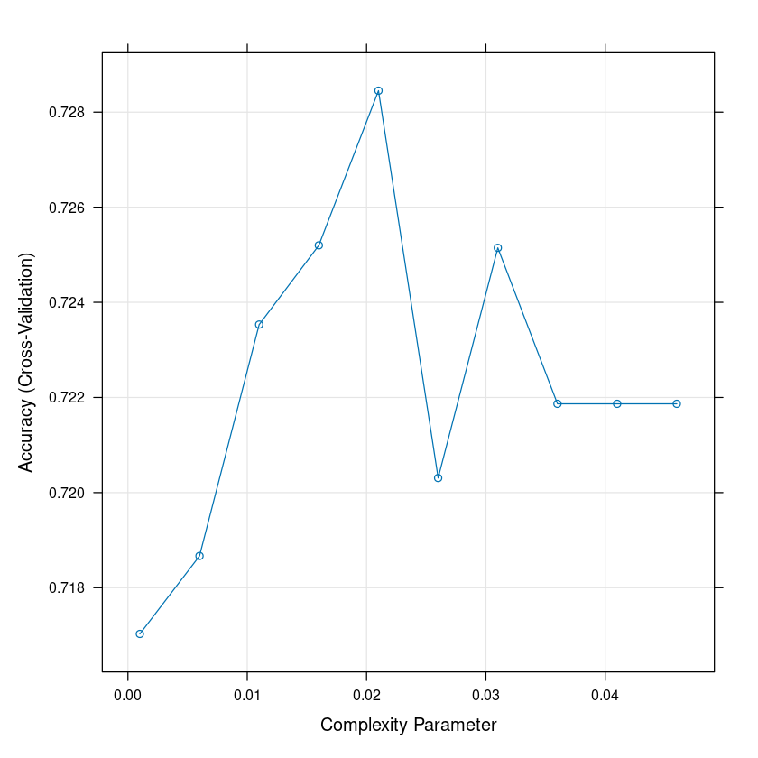

```r
# Define your parameter search space for cp
cp.grid = expand.grid(cp = seq(0.001, 0.05, by = 0.005))

fit.rpart1 = train(
  diabetes ~ .,
  data = train.dat,
  method = "rpart",
  trControl = ctrl,
  tuneGrid = cp.grid
)

# View tuning results
fit.rpart1
plot(fit.rpart1)
```

```r
#to tune multiple parameters like cp, minsplit, and maxdepth together, you’ll need to write a custom loop or use tuneGrid with a wrapper that builds the tree manually. For example:

grid = expand.grid(
  cp = c(0.001, 0.005, 0.01),
  minsplit = c(5, 10, 20),
  maxdepth = c(5, 10, 15)
)

results = data.frame()

for (i in 1:nrow(grid)) {
  cntrl = rpart.control(
    minsplit = grid$minsplit[i],
    maxdepth = grid$maxdepth[i],
    cp = grid$cp[i]
  )

  fit = rpart(diabetes ~ ., data = train.dat, method = "class", control = cntrl)
  pred = predict(fit, newdata = test.dat, type = "class")
  acc = mean(pred == test.dat$diabetes)

  results = rbind(results, data.frame(grid[i, ], Accuracy = acc))
}

results

#with automatic cp tuning via caret.

ctrl = trainControl(method = "cv", number = 10)

fit = train(
  diabetes ~ .,
  data = train.dat,
  method = "rpart",
  trControl = ctrl,
  tuneGrid = expand.grid(cp = seq(0.001, 0.05, by = 0.005)),
  control = rpart.control(minsplit = 10, minbucket = 3, maxdepth = 20)
)
```

A data.frame: 27 × 4

|  | cp <dbl> | minsplit <dbl> | maxdepth <dbl> | Accuracy <dbl> |
| --- | --- | --- | --- | --- |
| 1 | 0.001 | 5 | 5 | 0.7777778 |
| 2 | 0.005 | 5 | 5 | 0.7777778 |
| 3 | 0.010 | 5 | 5 | 0.7908497 |
| 4 | 0.001 | 10 | 5 | 0.7843137 |
| 5 | 0.005 | 10 | 5 | 0.7777778 |
| 6 | 0.010 | 10 | 5 | 0.7908497 |
| 7 | 0.001 | 20 | 5 | 0.7973856 |
| 8 | 0.005 | 20 | 5 | 0.7843137 |
| 9 | 0.010 | 20 | 5 | 0.7843137 |
| 10 | 0.001 | 5 | 10 | 0.7647059 |
| 11 | 0.005 | 5 | 10 | 0.7777778 |
| 12 | 0.010 | 5 | 10 | 0.7843137 |
| 13 | 0.001 | 10 | 10 | 0.7516340 |
| 14 | 0.005 | 10 | 10 | 0.7712418 |
| 15 | 0.010 | 10 | 10 | 0.7843137 |
| 16 | 0.001 | 20 | 10 | 0.7581699 |
| 17 | 0.005 | 20 | 10 | 0.7843137 |
| 18 | 0.010 | 20 | 10 | 0.7777778 |
| 19 | 0.001 | 5 | 15 | 0.7385621 |
| 20 | 0.005 | 5 | 15 | 0.7581699 |
| 21 | 0.010 | 5 | 15 | 0.7843137 |
| 22 | 0.001 | 10 | 15 | 0.7450980 |
| 23 | 0.005 | 10 | 15 | 0.7712418 |
| 24 | 0.010 | 10 | 15 | 0.7843137 |
| 25 | 0.001 | 20 | 15 | 0.7581699 |
| 26 | 0.005 | 20 | 15 | 0.7843137 |
| 27 | 0.010 | 20 | 15 | 0.7777778 |